# 11-Causal Inference

Author

Jordan Wozniak

Published

October 2, 2025

# 1 Intro

This is a [Quarto](https://quarto.org) file. Quarto enables you to weave together content and executable code into a finished document. When you execute code within the notebook, the results appear beneath the code. This allows you to share your analyses and results with others so that they can see the results in line with the code for reproducibility. Make sure to have only one sentence per line. To learn more about Quarto see https://quarto.org. For course instructions on using Quarto, see here: https://isaactpetersen.github.io/QuartoBlogFantasyFootball/posts/quarto-instructions/.

# 2 Preamble

## 2.1 Install Libraries

```r
#install.packages("remotes")
#remotes::install_github("DevPsyLab/petersenlab")
#remotes::install_github("FantasyFootballAnalytics/ffanalytics")

#update.packages(ask = FALSE)
```

## 2.2 Load Libraries

```r
library("dagitty")
library("ggdag")
```

# 3 Causal Diagrams

## 3.1 Diagram 1

Your research question is: What is the effect of past performance on future performance, in terms of fantasy points? Your hypothesis is that past performance and injury status influence a coach’s confidence in a player, which in turn influences their snap share, which in turn influences their number of touches/targets, which in turn influences their fantasy points. Draw a causal diagram (i.e., directed acyclic graph [DAG]) of the hypothesized causal model.

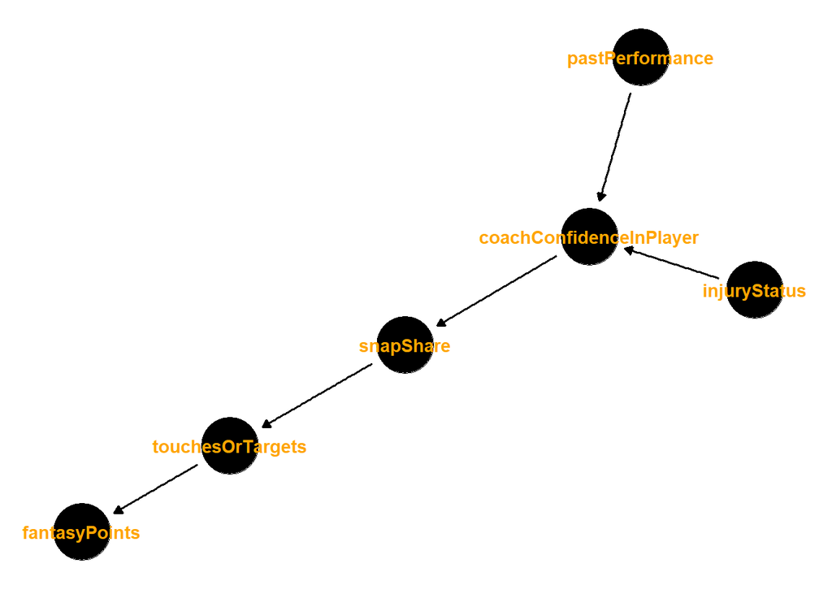

```r
causalDiagram1 <- ggdag::dagify(
  coachConfidenceInPlayer ~ pastPerformance + injuryStatus,
  snapShare ~ coachConfidenceInPlayer,
  touchesOrTargets ~ snapShare,
  fantasyPoints ~ touchesOrTargets
)

ggdag::ggdag(causalDiagram1, text_col = "orange") + theme_dag_blank()
```

Your prediction is that a player’s fantasy points in the prior week will predict their fantasy points in the future week. Using the `adjustmentSets()` function, which variable(s) in the model should you control for to obtain an unbiased estimate of the (total) association between past performance and future performance? Should you control for injury status? Should you control for snap share?

```r
dagitty::adjustmentSets(
  causalDiagram1,
  exposure = "pastPerformance",
  outcome = "fantasyPoints",
  effect = "total")
```

```
 {}
```

## 3.2 Diagram 2

Your research question is: How does a Quarterback’s intelligence influence their average time to throw? Your hypothesis is that more intelligent Quarterbacks process information more quickly, which leads them to picking a receiving target more quickly, which leads them to have a shorter average time to throw. You also expect there are factors, including age, that influence both (a) the Quarterback’s intelligence and (b) the average time to throw. Other factors that influence the Quarterback’s intelligence include their nutrition. Other factors that influence the player’s average time to throw include the strength of the offensive and defensive lines.

Draw the hypothesized causal diagram:

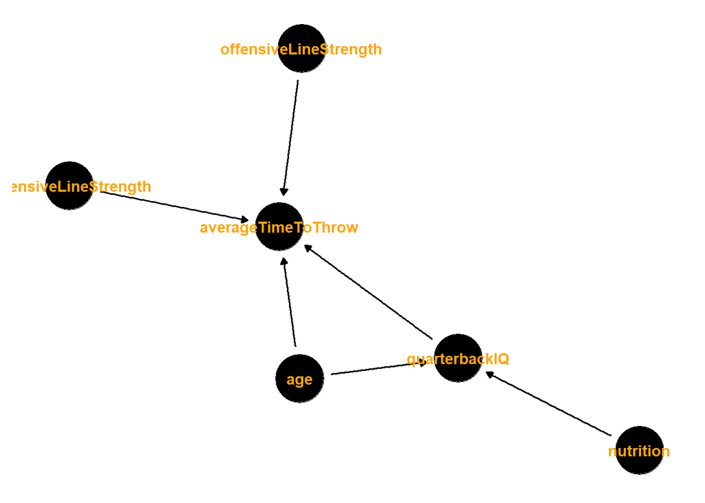

```r
causalDiagram2 <- ggdag::dagify(
quarterbackIQ ~ age + nutrition,
averageTimeToThrow ~ quarterbackIQ + age + offensiveLineStrength + defensiveLineStrength

)

ggdag::ggdag(causalDiagram2, text_col = "orange") + theme_dag_blank()
```

Your prediction is that Quarterbacks with higher intelligence scores on the Wonderlic test will show a faster average time to throw compared to Quarterbacks with lower intelligence scores on the Wonderlic test. Using the `adjustmentSets()` function, determine which variable(s) in the model you should control for to obtain an unbiased estimate of the (total) association between the Quarterback’s intelligence and their average time to throw.

```r
dagitty::adjustmentSets(
  causalDiagram2,
  exposure = "quarterbackIQ",
  outcome = "averageTimeToThrow",
  effect = "total")
```

```
{ age }
```

## 3.3 Diagram 3

In preparation for your next blog post, formulate a research question that you may be interested in testing. Now, formulate your hypothesis (i.e., proposed causal explanation) in regards to your hypothesis. Draw your own hypothesized causal model for your research question. Make sure to specify possible confounds in your causal diagram (i.e., factors that influence both your hypothesized cause and the hypothesized effect). For examples of research questions and hypotheses, see diagrams 1 and 2 (above).